# 03.1: Allometry

## **Content Description**

Allometry, is the covariation of shape with size, and is a critically-important pattern to evaluate in morphometric analyses. Here we show several analyses available in `geomorph` for investigating shape-size relationships.

## **1: Allometry: A Simple Example**

```r
library(geomorph)
```

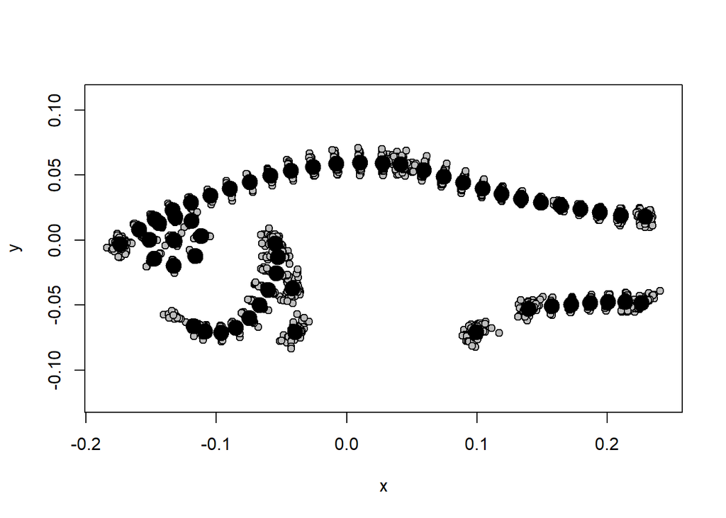

```r
data(pupfish)
plotAllSpecimens(pupfish$coords)  #NOTE: already GPA-aligned
```

```r
  #Y.gpa <- gpagen(pupfish$coords, print.progress = FALSE)    #GPA-alignment
pupfish$logSize <- log(pupfish$CS)
pupfish$Group <- interaction(pupfish$Pop, pupfish$Sex)

fit <- procD.lm(coords ~ logSize, data = pupfish, print.progress = FALSE)
anova(fit)
```

```
##
## Analysis of Variance, using Residual Randomization
## Permutation procedure: Randomization of null model residuals
## Number of permutations: 1000
## Estimation method: Ordinary Least Squares
## Sums of Squares and Cross-products: Type I
## Effect sizes (Z) based on F distributions
##
##           Df       SS        MS     Rsq      F      Z Pr(>F)
## logSize    1 0.014019 0.0140193 0.24886 17.229 4.3462  0.001 **
## Residuals 52 0.042314 0.0008137 0.75114
## Total     53 0.056333
## ---
## Signif. codes:  0 '***' 0.001 '**' 0.01 '*' 0.05 '.' 0.1 ' ' 1
##
## Call: procD.lm(f1 = coords ~ logSize, data = pupfish, print.progress = FALSE)
```

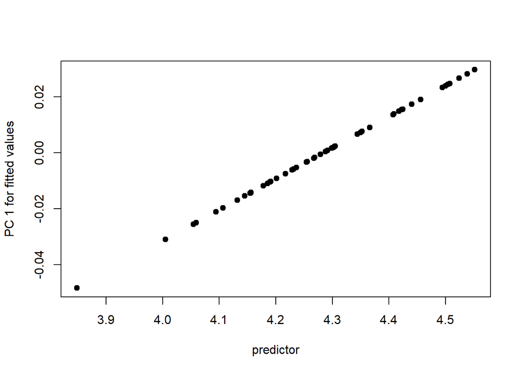

```r
# Predline (note: `plotAllometry` can also be used)
plot(fit, type = "regression", reg.type = "PredLine", predictor = pupfish$logSize, pch = 19)
```

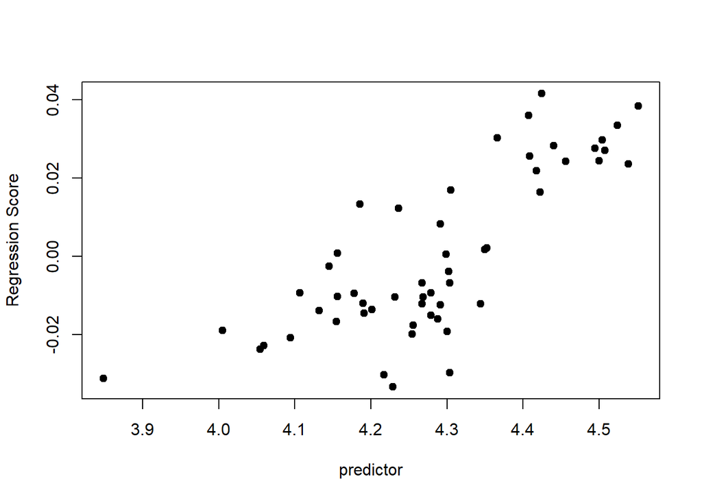

```r
# RegScore (note: `plotAllometry` can also be used)
plot(fit, type = "regression", reg.type = "RegScore", predictor = pupfish$logSize, pch = 19)
```

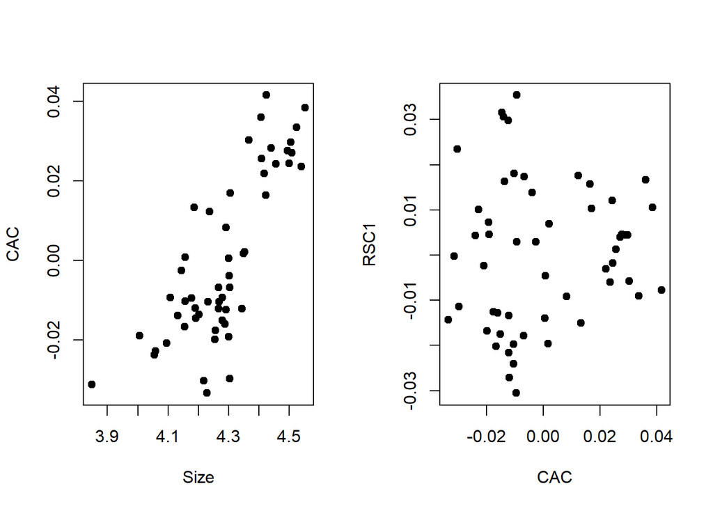

```r
# CAC
plotAllometry(fit, size = pupfish$logSize, logsz = FALSE, method = "CAC", pch = 19)
```

# Now we plot predicted shapes (see day 3 script)

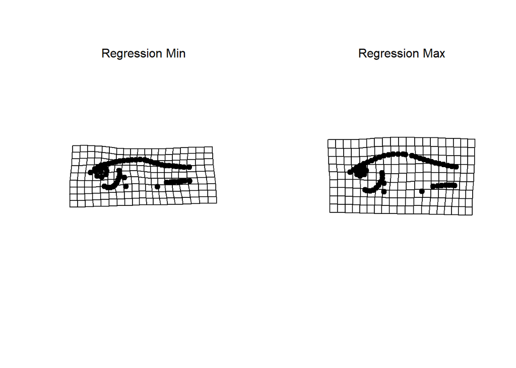

```r
M <- mshape(pupfish$coords)
preds <- shape.predictor(fit$GM$fitted, x= pupfish$logSize, Intercept = TRUE,
                         predmin = min(pupfish$logSize),
                         predmax = max(pupfish$logSize))
par(mfrow=c(1,2))
plotRefToTarget(M, preds$predmin, mag=1)
mtext("Regression Min")
plotRefToTarget(M, preds$predmax, mag=1)
mtext("Regression Max")
```

```r
par(mfrow=c(1,1))
```

## **2: Group Allometries**

Next, we add some biological realism, and consider the case of allometry patterns in multiple groups. This, of course, represents an ANCOVA design: analysis of covariance. It requires a more complex linear model, and affords additional possibilities in terms of analytical approaches, and visualizations.

#### Note! Before ever launching into an investigation of allometric differences, it is wise to ask if groups have a common allometry or unique allometrices.

```r
fit.common <- procD.lm(coords ~ logSize + Group,
                           data = pupfish, print.progress = FALSE)
fit.unique <- procD.lm(coords ~ logSize * Group,
                           data = pupfish, print.progress = FALSE)
anova(fit.unique)
```

```
##
## Analysis of Variance, using Residual Randomization
## Permutation procedure: Randomization of null model residuals
## Number of permutations: 1000
## Estimation method: Ordinary Least Squares
## Sums of Squares and Cross-products: Type I
## Effect sizes (Z) based on F distributions
##
##               Df       SS        MS     Rsq       F      Z Pr(>F)
## logSize        1 0.014019 0.0140193 0.24886 29.2078 5.0041  0.001 **
## Group          3 0.018230 0.0060766 0.32361 12.6601 6.4891  0.001 **
## logSize:Group  3 0.002004 0.0006682 0.03558  1.3921 1.1451  0.136
## Residuals     46 0.022079 0.0004800 0.39194
## Total         53 0.056333
## ---
## Signif. codes:  0 '***' 0.001 '**' 0.01 '*' 0.05 '.' 0.1 ' ' 1
##
## Call: procD.lm(f1 = coords ~ logSize * Group, data = pupfish, print.progress = FALSE)
```

In this case, the unique slopes are **not** an improvement of fit. This suggest that the slopes are relatively parallel. However, but for the purposes of illustration we will continue as if they were.

## **2a: Pairwise Comparisons**

Based on the outcome of a homogeneity of slopes test, one may wish to perform different types of pairwise comparisons. These come in the form of: 1) comparisons of adjusted least-squares means (common slopes), 2) comparisons of slope angles (unique slopes), 3) comparisons of regression lengths (unique slopes), and 4) comparisons of group disparity. For the present example, #2 and #3 are most appropriate to investigate.

```r
slope.pw <- pairwise(fit.unique, fit.null = fit.common,
                     groups = pupfish$Group,
                     covariate = pupfish$logSize, print.progress = FALSE)
summary(slope.pw, test.type = "VC", angle.type = "deg") # angular differences
```

```
##
## Pairwise comparisons
##
## Groups: Marsh.F Sinkhole.F Marsh.M Sinkhole.M
##
## RRPP: 1000 permutations
##
## Slopes (vectors of variate change per one unit of covariate
##         change, by group):
## Vectors hidden (use show.vectors = TRUE to view)
##
## Pairwise statistics based on slopes vector correlations (r)
##           and angles, acos(r)
## The null hypothesis is that r = 1 (parallel vectors).
## This null hypothesis is better treated as the angle
##           between vectors = 0
##                               r    angle UCL (95%)           Z Pr > angle
## Marsh.F:Sinkhole.F    0.6318267 50.81498  83.57546 -0.07310658      0.527
## Marsh.F:Marsh.M       0.6139591 52.12367  83.58445 -0.13196270      0.549
## Marsh.F:Sinkhole.M    0.4461018 63.50614  81.89039  0.66791084      0.273
## Sinkhole.F:Marsh.M    0.7175129 44.15048  63.60905  0.24275646      0.391
## Sinkhole.F:Sinkhole.M 0.4627734 62.43378  60.22153  1.77232308      0.037
## Marsh.M:Sinkhole.M    0.5629975 55.73665  65.19951  1.04510764      0.154
```

```r
summary(slope.pw, test.type = "dist", angle.type = "deg") # amount of shape change differences
```

```
##
## Pairwise comparisons
##
## Groups: Marsh.F Sinkhole.F Marsh.M Sinkhole.M
##
## RRPP: 1000 permutations
##
## Slopes (vectors of variate change per one unit of covariate
##         change, by group):
## Vectors hidden (use show.vectors = TRUE to view)
##
## Pairwise distances between slope vector
##             (end-points), plus statistics
##                                d UCL (95%)          Z Pr > d
## Marsh.F:Sinkhole.F    0.07848121 0.1621176 -0.9763904  0.838
## Marsh.F:Marsh.M       0.08279940 0.1640452 -0.9689342  0.829
## Marsh.F:Sinkhole.M    0.12322729 0.1610484  0.7139190  0.236
## Sinkhole.F:Marsh.M    0.06418279 0.1095190 -0.3981426  0.652
## Sinkhole.F:Sinkhole.M 0.11706696 0.1001323  2.2066562  0.015
## Marsh.M:Sinkhole.M    0.10863856 0.1132783  1.5445168  0.063
```

**Conclusion:** Not much going on for this example (**illustration purposes only**).

## **2b: Pairwise Comparisons**

This shows visually that the common slopes model is preferred.

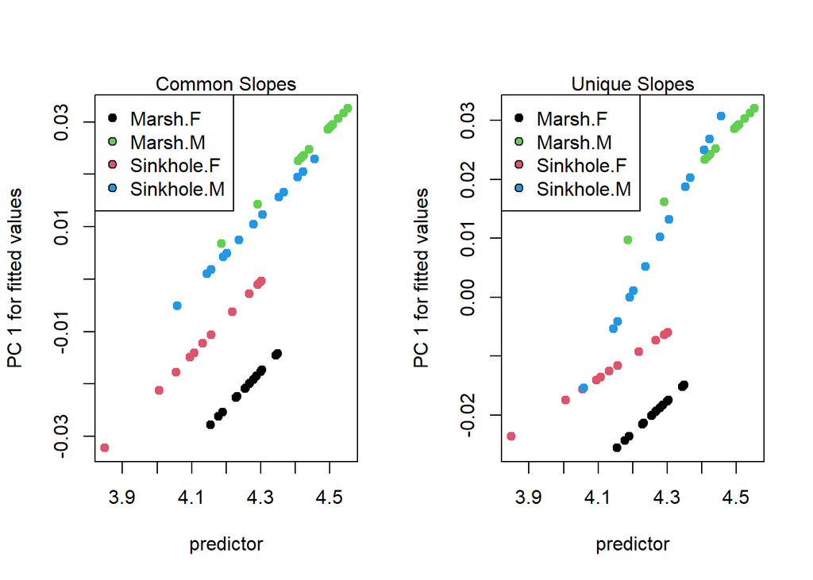

```r
par(mfcol = c(1,2))
plot(fit.common, type = "regression", predictor = pupfish$logSize,
     reg.type = "PredLine", pch=19, col = pupfish$Group)
legend("topleft", legend = unique(pupfish$Group), pch = 21, pt.bg = unique(pupfish$Group))
mtext("Common Slopes")
plot(fit.unique, type = "regression", predictor = pupfish$logSize,
     reg.type = "PredLine", pch=19, col = pupfish$Group)
legend("topleft", legend = unique(pupfish$Group), pch = 21, pt.bg = unique(pupfish$Group))
mtext("Unique Slopes")
```

```r
par(mfcol = c(1,1))
```

## **3: Size-Shape PCA**

One can also generate a plot of size-shape space (sensu Mitteroecker et al. 2004):

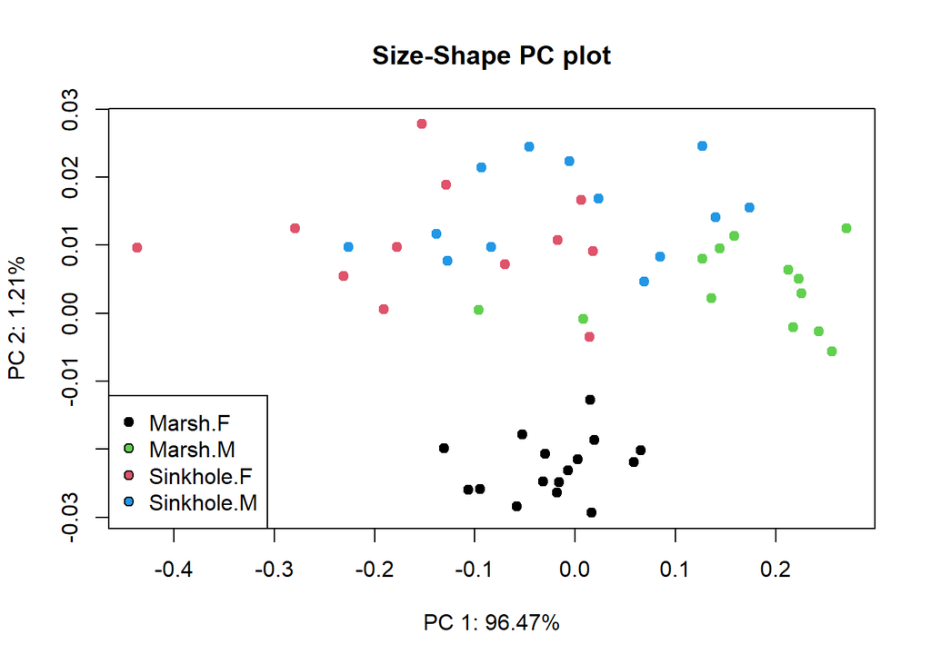

```r
pc.plot <- plotAllometry(fit.unique, size = pupfish$logSize, logsz = FALSE, method = "size.shape", pch = 19, col = pupfish$Group)
legend("bottomleft", legend = unique(pupfish$Group), pch = 21, pt.bg = unique(pupfish$Group))
```

```r
summary(pc.plot$size.shape.PCA)
```

```
## Importance of components:
##                           PC1     PC2     PC3      PC4     PC5      PC6
## Standard deviation     0.1474 0.01651 0.01485 0.007529 0.00707 0.006295
## Proportion of Variance 0.9647 0.01209 0.00978 0.002520 0.00222 0.001760
## Cumulative Proportion  0.9647 0.97675 0.98653 0.989050 0.99126 0.993020
##                             PC7      PC8     PC9     PC10     PC11     PC12
## Standard deviation     0.005656 0.004491 0.00407 0.003508 0.003013 0.002929
## Proportion of Variance 0.001420 0.000900 0.00074 0.000550 0.000400 0.000380
## Cumulative Proportion  0.994440 0.995340 0.99607 0.996620 0.997020 0.997400
##                           PC13     PC14     PC15     PC16    PC17     PC18
## Standard deviation     0.00262 0.002505 0.002361 0.002194 0.00212 0.001935
## Proportion of Variance 0.00030 0.000280 0.000250 0.000210 0.00020 0.000170
## Cumulative Proportion  0.99771 0.997990 0.998240 0.998450 0.99865 0.998820
##                            PC19     PC20     PC21     PC22     PC23     PC24
## Standard deviation     0.001782 0.001662 0.001616 0.001509 0.001413 0.001329
## Proportion of Variance 0.000140 0.000120 0.000120 0.000100 0.000090 0.000080
## Cumulative Proportion  0.998960 0.999080 0.999190 0.999300 0.999380 0.999460
##                            PC25     PC26     PC27      PC28      PC29      PC30
## Standard deviation     0.001123 0.001104 0.001014 0.0009936 0.0009728 0.0008576
## Proportion of Variance 0.000060 0.000050 0.000050 0.0000400 0.0000400 0.0000300
## Cumulative Proportion  0.999520 0.999570 0.999620 0.9996600 0.9997000 0.9997400
##                             PC31      PC32      PC33      PC34     PC35
## Standard deviation     0.0008072 0.0007869 0.0007659 0.0006959 0.000669
## Proportion of Variance 0.0000300 0.0000300 0.0000300 0.0000200 0.000020
## Cumulative Proportion  0.9997700 0.9997900 0.9998200 0.9998400 0.999860
##                             PC36      PC37      PC38      PC39     PC40
## Standard deviation     0.0006259 0.0005974 0.0005768 0.0005292 0.000494
## Proportion of Variance 0.0000200 0.0000200 0.0000100 0.0000100 0.000010
## Cumulative Proportion  0.9998800 0.9998900 0.9999100 0.9999200 0.999930
##                             PC41      PC42      PC43      PC44      PC45
## Standard deviation     0.0004724 0.0004492 0.0004368 0.0004183 0.0003844
## Proportion of Variance 0.0000100 0.0000100 0.0000100 0.0000100 0.0000100
## Cumulative Proportion  0.9999400 0.9999500 0.9999600 0.9999700 0.9999700
##                             PC46      PC47      PC48      PC49      PC50
## Standard deviation     0.0003406 0.0003186 0.0002964 0.0002685 0.0002631
## Proportion of Variance 0.0000100 0.0000000 0.0000000 0.0000000 0.0000000
## Cumulative Proportion  0.9999800 0.9999800 0.9999900 0.9999900 0.9999900
##                             PC51     PC52      PC53      PC54
## Standard deviation     0.0002355 0.000215 0.0002037 6.546e-17
## Proportion of Variance 0.0000000 0.000000 0.0000000 0.000e+00
## Cumulative Proportion  1.0000000 1.000000 1.0000000 1.000e+00
```